# Week of 06-06-2022

Zachary Rowson

6/7/2022

## Introduction

In this document I will attempt to fit non-linear mixed effects models to the Loperamide exposure data. If this is completed, I will evaluate the quality of fit and compare the fits to the quadratic model to evaluate if the movement data is sufficiently modeled.

## Load Loperamide Data and Visualize

```r
load("../data/Padilla_DNT60_Loperamide.rda")

# Split Light
data <- copy(Padilla_DNT60_Loperamide)
data.L <- Padilla_DNT60_Loperamide[t%in%11:30]
data.D <- Padilla_DNT60_Loperamide[t%in%31:50]

# Shift time measurements and save concentration as a factor
data.L$t <- data.L$t - mean(data.L$t)
data.L$conc <- as.factor(data.L$conc)
data.D$t <- data.D$t - mean(data.D$t)
data.D$conc <- as.factor(data.D$conc)

# Identify individuals to remove
remove <- Padilla_DNT60_Loperamide[is.na(y), unique(fishID)]
```

```r
# Add well location, inside vs. outside, as co-variate
data.L[rowi%in%c(1,8), well_loc:="outside"][coli%in%c(1,12), well_loc:="outside"]
data.L[is.na(well_loc), well_loc:="inside"]
data.D[rowi%in%c(1,8), well_loc:="outside"][coli%in%c(1,12), well_loc:="outside"]
data.D[is.na(well_loc), well_loc:="inside"]

# Transform data
data.L.sqrt <- copy(data.L)
data.L.sqrt[, sqrty := sqrt(y)]
data.D.sqrt <- copy(data.D)
data.D.sqrt[, sqrty := sqrt(y)]
```

```r
Light.sqrt <- groupedData(sqrty ~ t | fishID, data = as.data.frame(data.L.sqrt[!(fishID%in%remove)]), order.groups = FALSE)
Dark.sqrt <- groupedData(sqrty ~ t | fishID, data = as.data.frame(data.D.sqrt[!(fishID%in%remove)]), order.groups = FALSE)
```

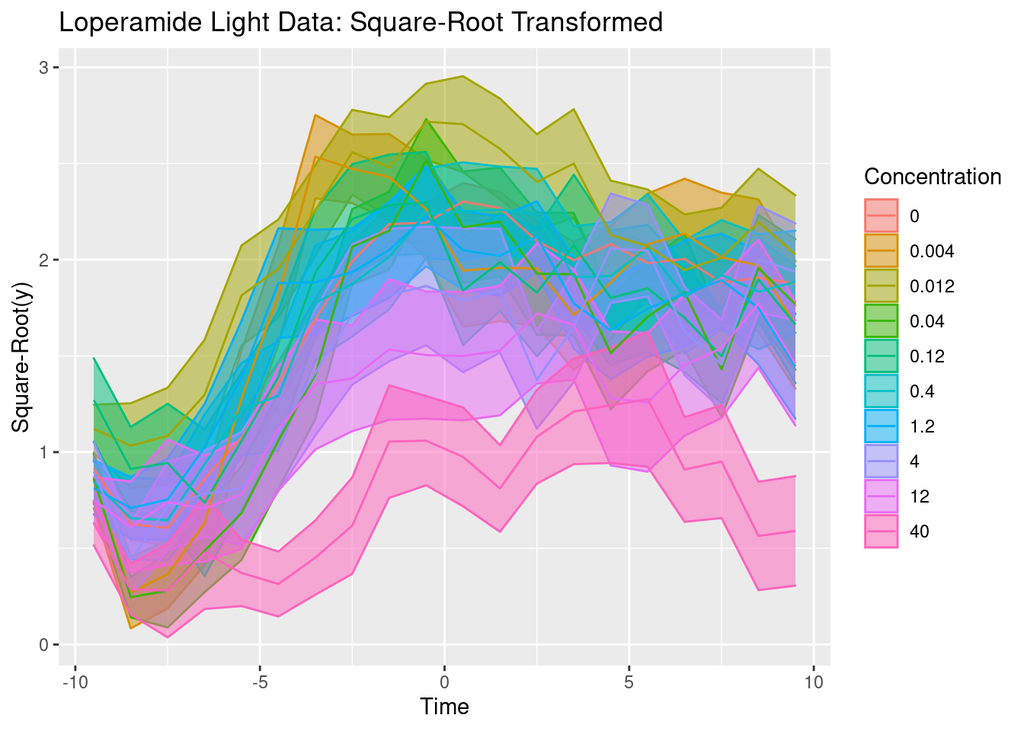

```r
avg_func <- function(...) {
  avg <- mean(...,na.rm=TRUE)
  SE <- stats::sd(..., na.rm=TRUE) / sqrt(length(...))

  data.frame(y=avg, ymin=avg-SE, ymax=avg+SE)
}

# Plots
ggplot(data.L.sqrt, aes(x=t,y=sqrty,fill=conc,color=conc)) +
  stat_summary(fun.data=avg_func, geom="ribbon", alpha=0.5) +
  stat_summary(fun.data=avg_func, geom="line") +
  labs(title="Loperamide Light Data: Square-Root Transformed",
       fill="Concentration", color="Concentration",
       x="Time", y="Square-Root(y)")
```

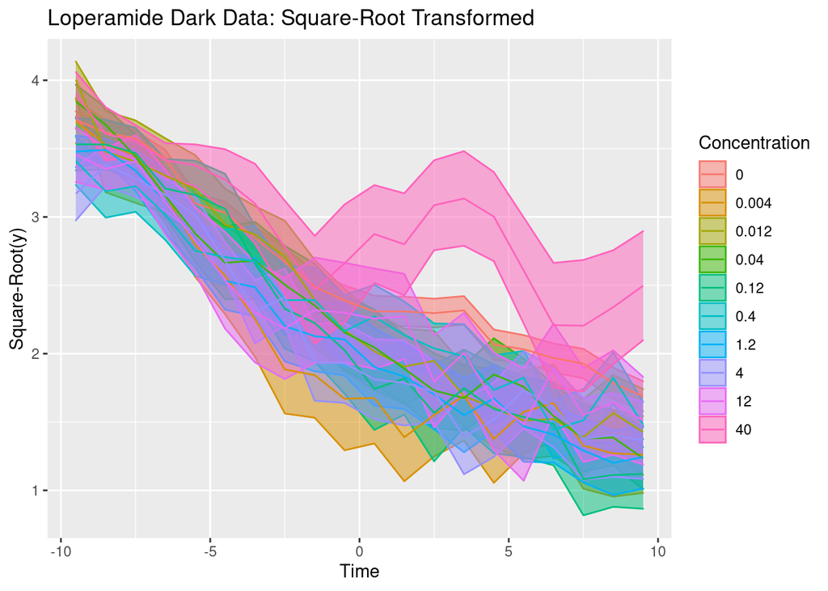

```r
ggplot(data.D.sqrt, aes(x=t,y=sqrty,fill=conc,color=conc)) +
  stat_summary(fun.data=avg_func, geom="ribbon", alpha=0.5) +
  stat_summary(fun.data=avg_func, geom="line") +
  labs(title="Loperamide Dark Data: Square-Root Transformed",
       fill="Concentration", color="Concentration",
       x="Time", y="Square-Root(y)")
```

# Attempt to Fit Non-Linear Functions

As a first trial I will fit a more flexible polynomial function to see if this results in better fits.

```r
normAIC <- function(zz) {
    zz$AIC <- zz$AIC - min(zz$AIC)
    indx <- order(zz$AIC)
    zz[indx,]
}
```

```r
ctrl <- lmeControl(opt = "optim", niterEM = 200, msTol = 1e-20, msMaxIter = 1000, apVar = FALSE)
lmm2 <- lme(sqrty ~ conc*poly(t,degree=2,raw=TRUE),
            data = Light.sqrt,
            random = reStruct(~poly(t,degree=2,raw=TRUE)|fishID,REML=FALSE,pdClass="pdSymm"),
            correlation = corAR1(,form=~t|fishID),
            method = "ML",
            control = ctrl)
lmm4 <- lme(sqrty ~ conc*poly(t,degree=4,raw=TRUE),
            data = Light.sqrt,
            random = reStruct(~poly(t,degree=4,raw=TRUE)|fishID,REML=FALSE,pdClass="pdSymm"),
            correlation = corAR1(,form=~t|fishID),
            method = "ML",
            control = ctrl)
```

[output not shown]

```r
lmm5 <- lme(sqrty ~ conc*poly(t,degree=5,raw=TRUE),
            data = Light.sqrt,
            random = reStruct(~poly(t,degree=5,raw=TRUE)|fishID,REML=FALSE,pdClass="pdSymm"),
            correlation = corAR1(,form=~t|fishID),
            method = "ML",
            control = ctrl)
```

```
## Error in logLik.reStruct(object, conLin): NA/NaN/Inf in foreign function call (arg 3)
```

```r
zz <- AIC(lmm2, lmm4, lmm5)
```

```
## Error in lapply(list(object, ...), ll): object 'lmm5' not found
```

```r
normAIC(zz)
```

```
## Error in normAIC(zz): object 'zz' not found
```

Fit a logistic model to the data in the Light.

```r
ctrl <- lmeControl(opt = "optim", niterEM = 200, msTol = 1e-20, msMaxIter = 1000, apVar = FALSE)

nls.Light <- nlsList(sqrty ~ SSfpl(t, phi1, phi2, phi3, phi4),
                     data = Light.sqrt,
                     control = ctrl)
```

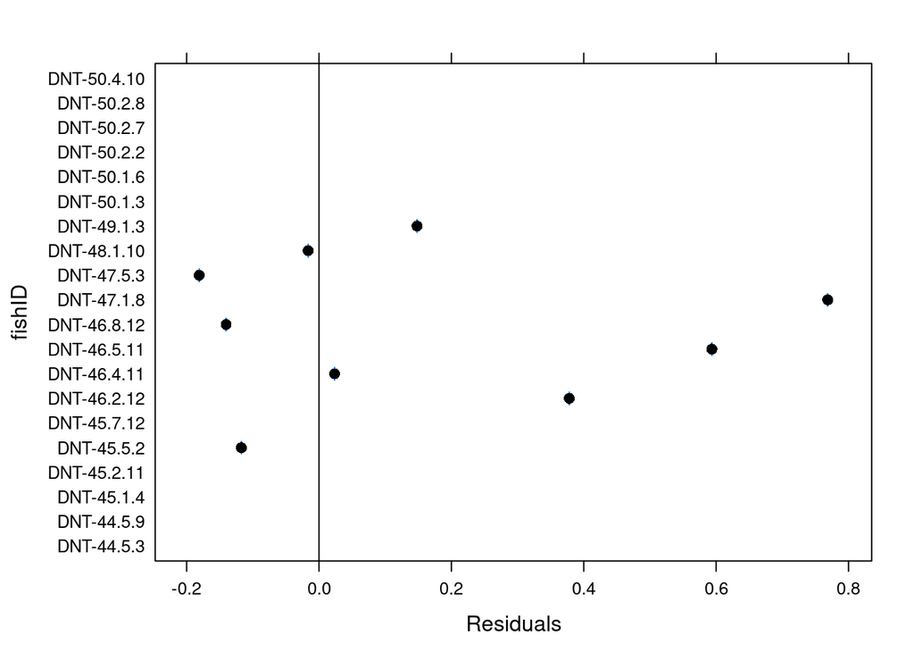

```r
sample <- sample(Light.sqrt$fishID, 20)
plot(nls.Light, fishID ~ resid(.), abline = 0, subset=sample)
```

```r
nlmm.Light <- nlme(sqrty ~ SSfpl(t, phi1, phi2, phi3, phi4),
                   random = pdDiag(phi1 + phi2 + phi3 + phi4 ~ 1),
                   data = Light.sqrt,
                   control = ctrl)
```

```
## Error in logLik.lmeStructInt(nlmeSt, nlmePars): NA/NaN/Inf in foreign function call (arg 1)
```

## Try Something New

Attempt to fit the models another way. Non linear models require initial estimates for parameter values. We need to provide initial estimates for the asymptotic speed that zebrafish take, the time at which the inflection point occurs, and the time elapsed between zebrafish reaching inflection point and obtaining 3/4 of their maximum speed.

I will estimate these values from the sample averaged trend line. To simplify this process I will work only with a random sample of the control fish.

```r
ctrlFishID <- data[wllt=="v" & !(fishID%in%remove), unique(fishID)]
fishSample <- sample(ctrlFishID, 16)
data_sample <- data[fishID%in%fishSample]

data_sample.L <- data_sample[t%in%11:30]

# Shift time measurements and save concentration as a factor
data_sample.L$t <- data_sample.L$t - mean(data_sample.L$t)
data_sample.L$conc <- as.factor(data_sample.L$conc)

# Transform data
data_sample.L.sqrt <- copy(data_sample.L)
data_sample.L.sqrt[, sqrty := sqrt(y)]
```

```r
sample.L <- groupedData(sqrty ~ t | fishID, data = as.data.frame(data_sample.L.sqrt),
                        order.groups = FALSE)
```

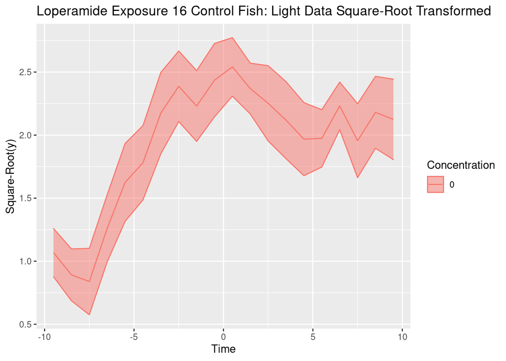

```r
ggplot(sample.L, aes(x=t,y=sqrty,fill=conc,color=conc)) +
  stat_summary(fun.data=avg_func, geom="ribbon", alpha=0.5) +
  stat_summary(fun.data=avg_func, geom="line") +
  labs(title="Loperamide Exposure 16 Control Fish: Light Data Square-Root Transformed",
       fill="Concentration", color="Concentration",
       x="Time", y="Square-Root(y)")
```

Plot individual tracks of the zebrafish.

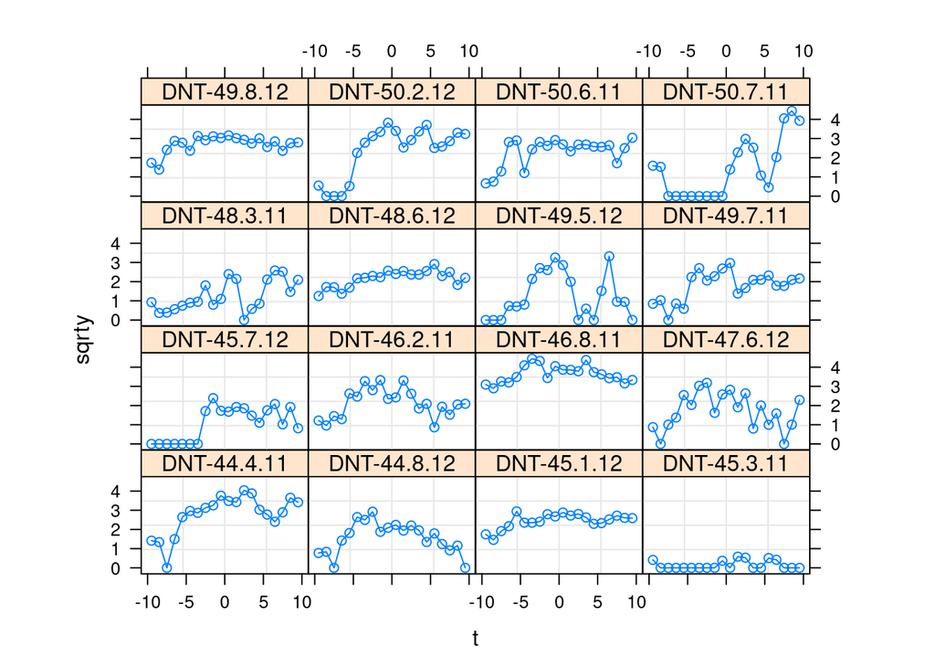

```r
plot(sample.L)
```

Tracks of zebrafish are not clearly sigmoid. We will have to use a model with variable lower asymptote or else individual models will be too constrained. I worry about the ability of the sigmoid model to capture the high variability of these zebrafish tracks.

```r
logist <- deriv( ~(AsymL-AsymU) / (1 + exp(-(x-xmid)/scal)),
                c("AsymU", "AsymL", "xmid", "scal"),
                function(x, AsymU, AsymL, xmid, scal) {})
```

```r
nls(sqrty ~ logist(t, AsymU, AsymL, xmid, scal),
    start = c(AsymU=1.75, AsymL=0.75, xmid=-3, scal=1.5),
    data = sample.L)
```

```
## Error in nlsModel(formula, mf, start, wts): singular gradient matrix at initial parameter estimates
```

Visually estimating initial parameter estimates is not working. Instead establish a “selfStart” object which uses a function to create initial parameter estimates.

```r
logistInit <- function(mCall, LHS, data) {
  xy <- sortedXyData(mCall[["x"]], LHS, data)
  if(nrow(xy) < 3) {
    stop("Too few distinct input values to fit a logistic")
  }
  AsymU <- max(abs(xy[,"y"]))
  AsymL <- min(abs(xy[,"y"]))
  xmid <- NLSstClosestX(xy, 0.5 * AsymU)
  scal <- NLSstClosestX(xy, 0.75 * AsymU) - xmid
  value <- c(AsymU, AsymL, xmid, scal)
  names(value) <- mCall[c("AsymU","AsymL","xmid","scal")]
  value
}
```

```r
logist1 <- selfStart(logist, initial = logistInit)
```

View the initial estimates using the algorithm.

```r
getInitial(sqrty ~ logist1(t, AsymU, AsymL, xmid, scal),
           data = sample.L)
```

```
##      AsymU      AsymL       xmid       scal
##  2.5410564  0.8384068 -6.4736024 10.5503008
```

I don’t understand these estimates. Not a good sign. Fit model despite this.

```r
nls(sqrty ~ logist1(t, AsymU, AsymL, xmid, scal),
    data = sample.L)
```

```
## Error in nlsModel(formula, mf, start, wts): singular gradient matrix at initial parameter estimates
```

```r
logist <- deriv( ~ Asym/(1+exp(-(x - xmid)/scal)), c("Asym","xmid","scal"),
                function(x, Asym, xmid, scal) {})
```